# Activity Class Prediction–Project assignment of Practical Machine Learning

pickacarrot

April 24, 2015

# Loading data

The training data for this project are available here: https://d396qusza40orc.cloudfront.net/predmachlearn/pml-training.csv

The testing data can be downloaded here: https://d396qusza40orc.cloudfront.net/predmachlearn/pml-testing.csv

After dowaloading data sources, read the training data and testing data into “train” and “test” respectively:

```r
train <- read.csv("pml-training.csv")
test <- read.csv("pml-testing.csv")
```

# Initial environment

In order to finish this project, we weed several packages:

```r
library(lattice)
```

```r
library(ggplot2)
library(caret)
library(rpart)
library(rattle)
```

Additionally, for the purpose of reproduceablity, we set a seed:

```r
set.seed(8787)
```

# Preprocessing data

•Remove the index and usernames

Obviously, index and usernames are not predictors for activity class. So we remove the first two columns of train dataset:

```r
training <- train[,-c(1,2)]
```

•Remove columns with too many NAs

If one column has more than 50% missing values, we believe that it is not a good predictor and remove it.

```r
training1<- training
for(i in 1:length(training)) {
        if( sum( is.na( training[, i] ) ) /nrow(training) >= .5 ) {
        for(j in 1:length(training1)) {
            if( length( grep(names(training[i]), names(training1)[j]) ) ==1)  {
                training1 <- training1[ , -j]
            }
        }
    }
}
```

•Remove columns with near zero variance

If a certain variable has variance close to zero, it has little impact on prediction results and can be removed for a cleaner dataset.

```r
nzv <- nearZeroVar(training1)
training2 <- training1[,-nzv]
```

# Using decision tree for prediction

Applying the rpart function to the clean dataset “training2”, we can get a decision tree for predicting activity class.

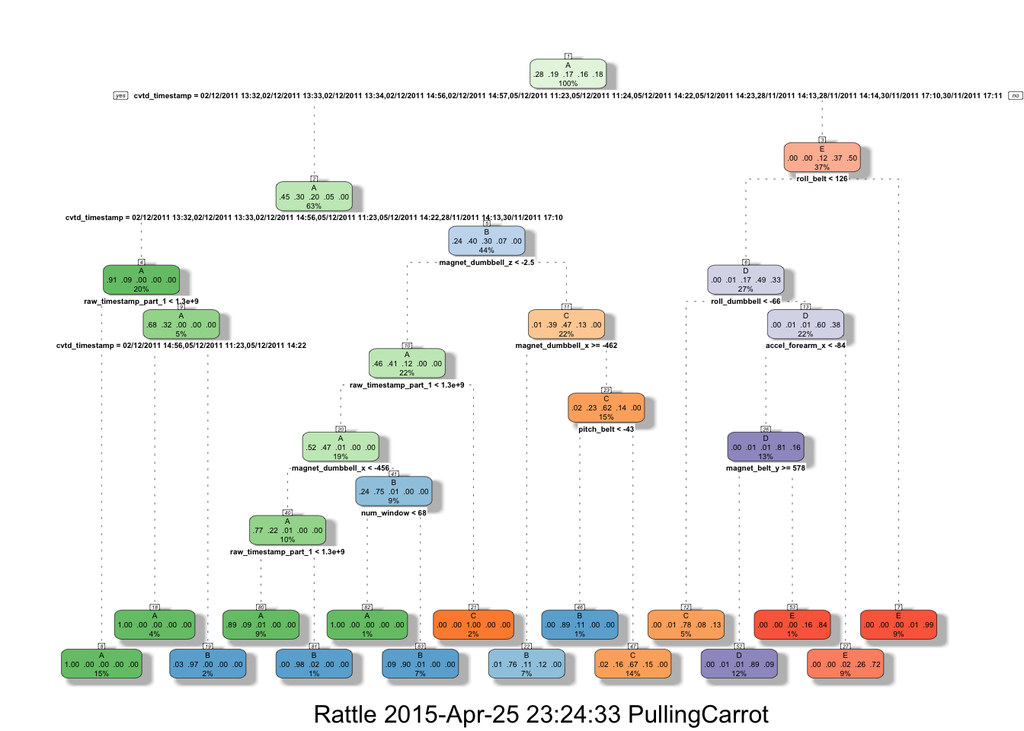

```r
tree <- rpart(classe ~ ., data=training2, method="class")
fancyRpartPlot(tree)
```

# Using K-fold cross validation to evaluate the decision tree model

Before using the decision tree to predict the testing dataset, we want to estimate how accurate the model could be. In order to evaluate it, we can randomly split the clean training data into 10 groups. In the first round, we take the first group out to be testing group, then generate the model from the remaining 9 groups. Apply the model to the first group and get the misclassification error. Repeat this step to the other groups. This is 10-fold cross validation.

```r
n=dim(training2)[1]
k=10
kfold_index=sample(1:k,n,replace=TRUE)
kfold_test_error=rep(0,k)

for(i in 1:k){
kfold_train=training2[kfold_index!=i,]
kfold_test=training2[kfold_index==i,]
modFit <- rpart(classe ~ ., data=kfold_train, method="class")
prediction <- predict(modFit, kfold_test, type="class")
kfold_test_error[i] = 1-(sum(prediction==kfold_test[,57]))/nrow(kfold_test)
}
kfold_test_error
```

```
##  [1] 0.1300357 0.1214859 0.1273657 0.1349569 0.1292135 0.1287840 0.1295716
##  [8] 0.1345401 0.1447846 0.1271143
```

Average the 10 misclassification errors and this is also the estmatied out of sampel error we have.

```r
aver_error = mean(kfold_test_error)
aver_error
```

```
## [1] 0.1307852
```

# Predict activity class of the testing dataset

```r
dim(test)
```

```
## [1]  20 160
```

We apply the model testing dataset:

```r
colnames <- names(training2)
testing <- test[,names(test)%in%colnames]
answers <- predict(modFit, testing, type="class")
answers
```

```
##  1  2  3  4  5  6  7  8  9 10 11 12 13 14 15 16 17 18 19 20
##  B  A  C  A  A  E  D  C  A  A  B  C  B  A  E  E  A  B  B  B
## Levels: A B C D E
```

We submit the predictions to the programming assignment and get 18/20 accuracy.